# VSR & PVZ: Heloisa Ihle Giamberardino

Análise: [Henrique Laureano](https://henriquelaureano.github.io/)

Last modification on* 2021-09-25 11:05:56

> Vírus Sincicial Respiratório (VSR) e Palivizumabe (PVZ)

# RSV

## a)

> **Descrever as características clínicas, epidemiológicas e desfechos de crianças ≤ 2 anos de idade, hospitalizadas com diagnóstico de Síndrome Respiratória Aguda Grave (SRAG), comparando pacientes positivos para VSR e pacientes positivos para outros vírus respiratórios**

> No painél seguinte coloquei `Sexo` e `PVZ`, mas posso inserir mais ou substituir pela figura que você achar melhor.

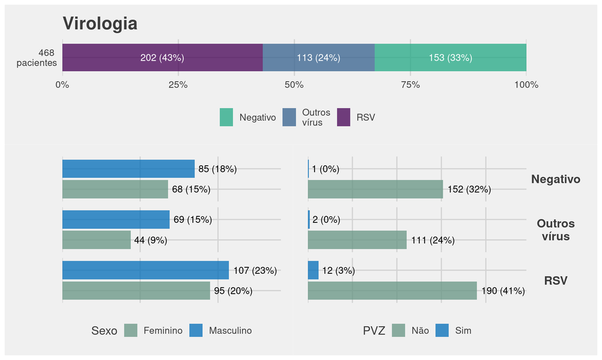

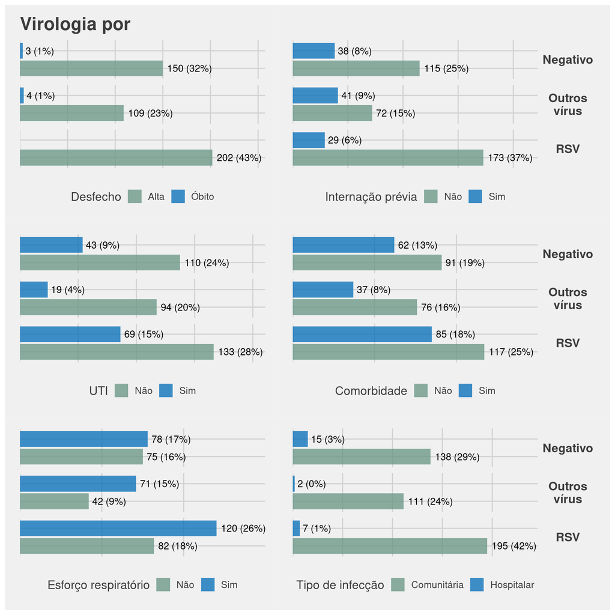

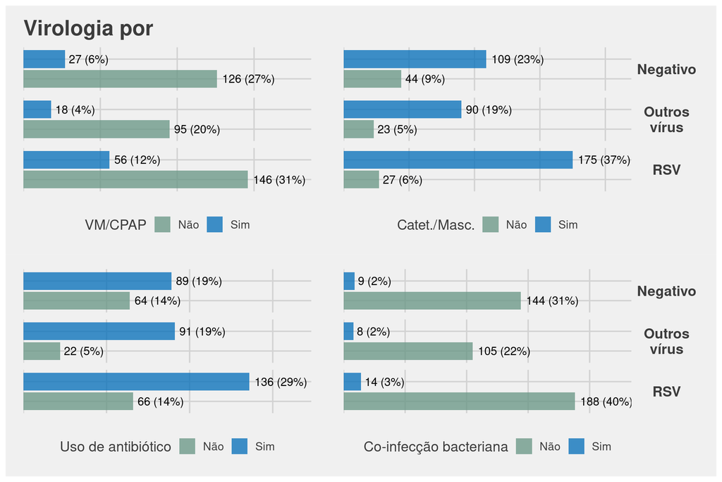

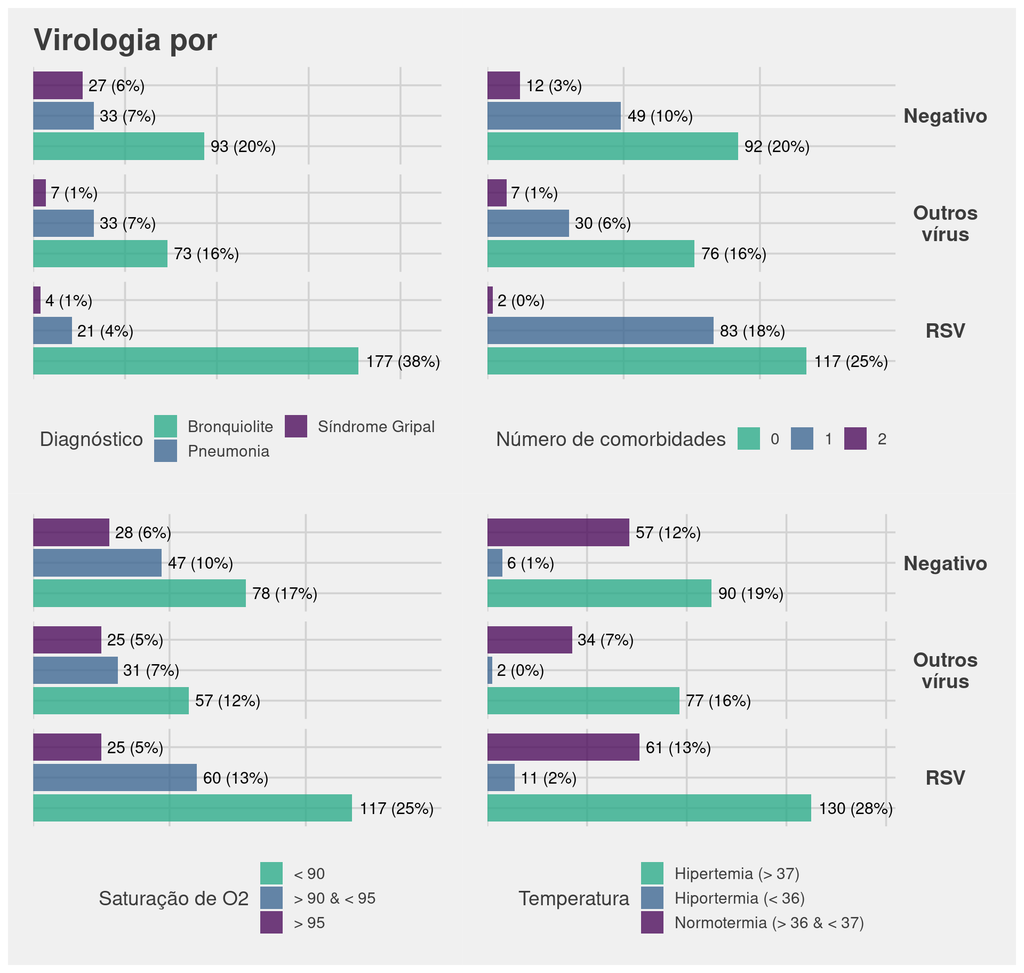

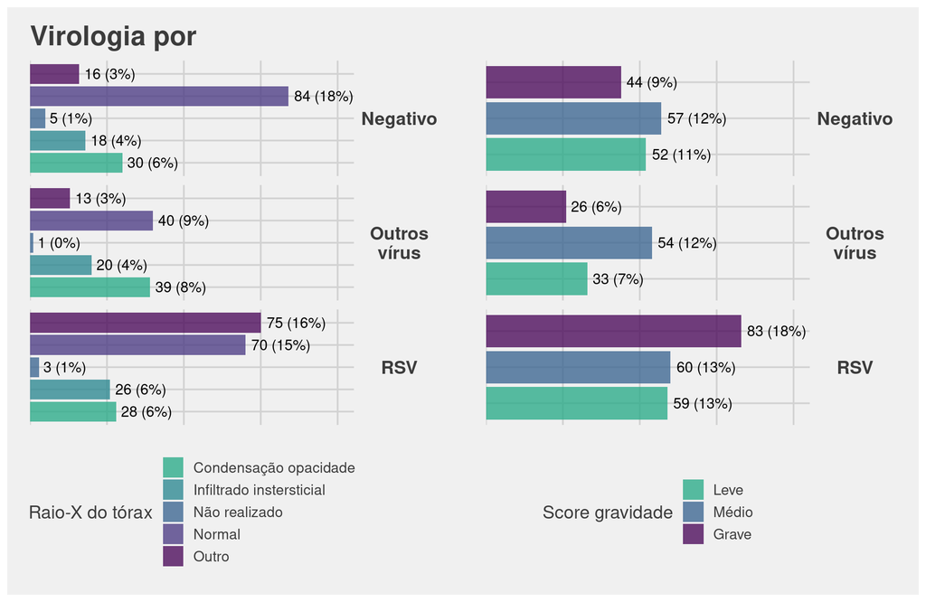

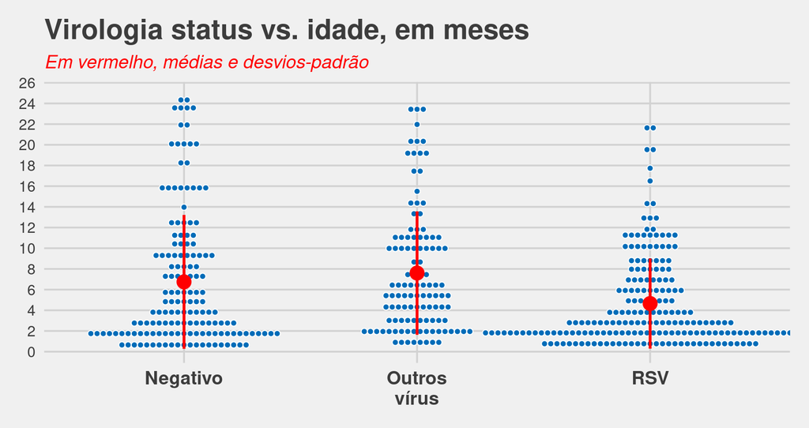

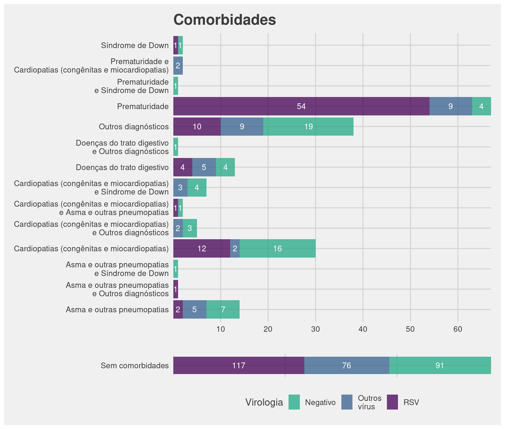

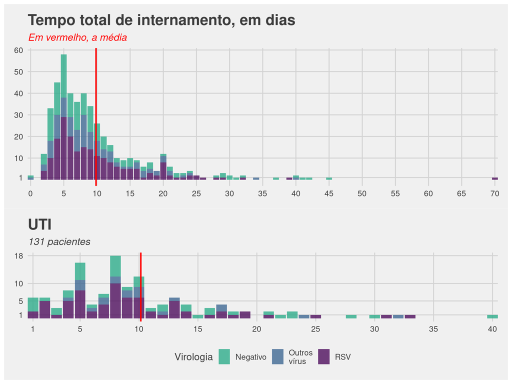

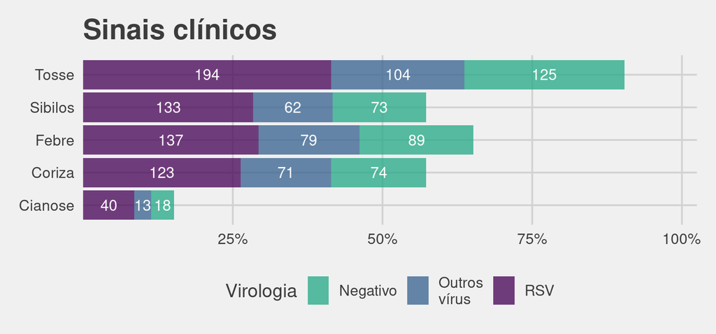

## b)

> **Correlacionar a gravidade da doença com o perfil molecular do VSR**

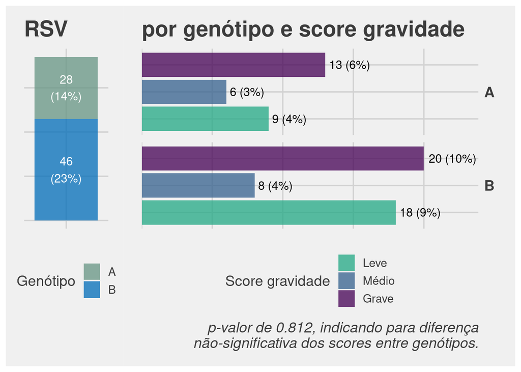

## c)

> **Comparar fatores genéticos das IL28B de susceptibilidade em crianças ≤ 2 anos de idade, previamente saudáveis, sem comorbidades, entre infectadas por RSV e outros vírus respiratórios**

> *Dados recentes da literatura relacionam os SNPs das regiões e rs8099917 da interleucina 28B (IL28B) com susceptibilidade ou proteção para doenças infeciosas.Os polimorfismos SNPs rs12979860 e rs8099917 do gene 28B da interleucina-28B são conhecidos por influenciar a expressão do interferon lambda 3*

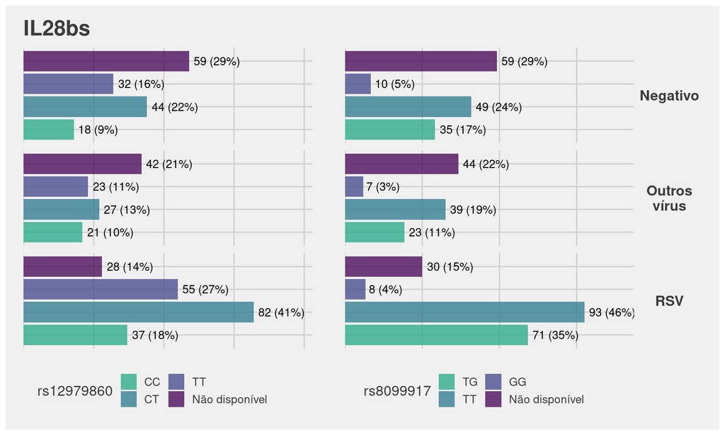

> *Para o cálculo dos seguintes p-valores, via teste qui-quadrado, foram descartadas a virologia `negativo` e os IL28bs `não disponíveis`*

> Olhando para o IL28b `rs12979860`, existe diferença estatísticamente significativa entre as frequências de CC, CT e TT, do vírus RSV para outros vírus? **Não, p-valor de 0.298**

> Olhando para o IL28b `rs8099917`, existe diferença estatísticamente significativa entre as frequências de TT, TG e GG, do vírus RSV para outros vírus? **Não, p-valor de 0.198**

> Agora,

> Olhando para o IL28b `rs12979860` apenas no vírus RSV, existe diferença estatísticamente significativa entre as frequências de CC, CT e TT? **Sim, p-valor de 0.000144**

> Olhando para o IL28b `rs8099917` apenas no vírus RSV, existe diferença estatísticamente significativa entre as frequências de TT, TG e GG? **Sim, p-valor de 0.00000000000000181 (1.81e-15)**

> Olhando para o IL28b `rs12979860` apenas nos outros vírus, existe diferença estatísticamente significativa entre as frequências de CC, CT e TT? **Não, p-valor de 0.674**

> Olhando para o IL28b `rs8099917` apenas nos outros virus, existe diferença estatísticamente significativa entre as frequências de TT, TG e GG? **Sim, p-valor de 0.0000147**

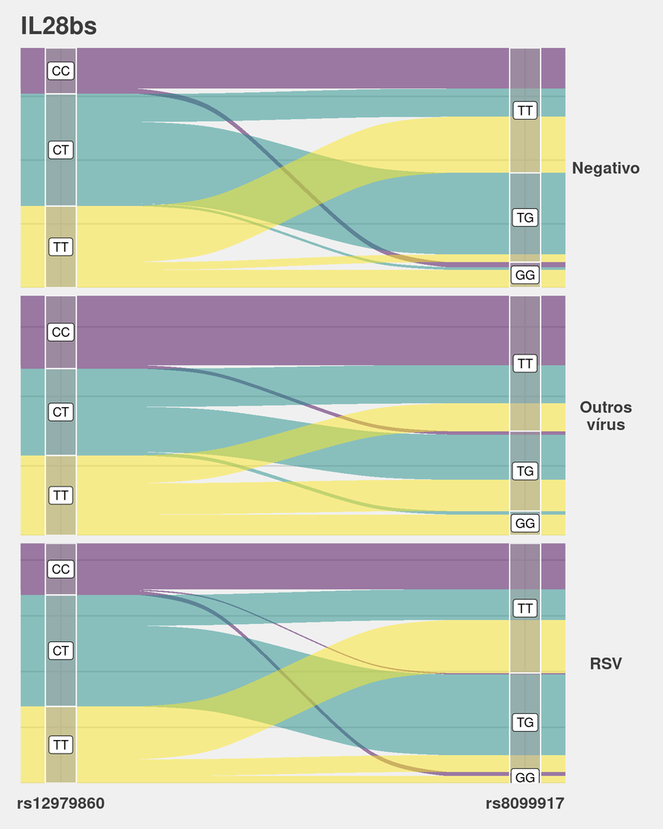

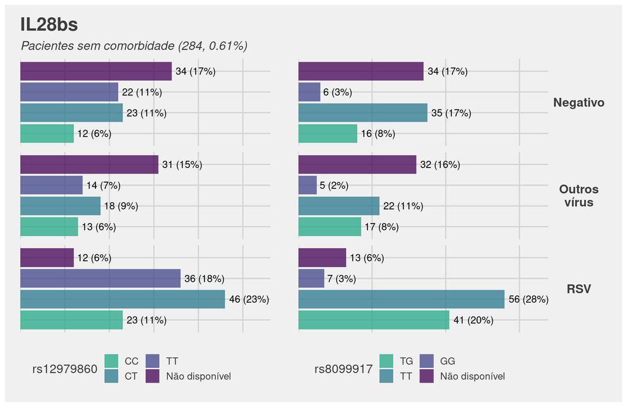

> Olhando para o IL28b `rs12979860`, existe diferença estatísticamente significativa entre as frequências de CC, CT e TT, do vírus RSV para outros vírus? **Não, p-valor de 0.656**

> Olhando para o IL28b `rs8099917`, existe diferença estatísticamente significativa entre as frequências de TT, TG e GG, do vírus RSV para outros vírus? **Não, p-valor de 0.634**

> Agora,

> Olhando para o IL28b `rs12979860` apenas no vírus RSV, existe diferença estatísticamente significativa entre as frequências de CC, CT e TT? **Sim, p-valor de 0.0224**

> Olhando para o IL28b `rs8099917` apenas no vírus RSV, existe diferença estatísticamente significativa entre as frequências de TT, TG e GG? **Sim, p-valor de 0.0000000127**

> Olhando para o IL28b `rs12979860` apenas nos outros vírus, existe diferença estatísticamente significativa entre as frequências de CC, CT e TT? **Não, p-valor de 0.627**

> Olhando para o IL28b `rs8099917` apenas nos outros virus, existe diferença estatísticamente significativa entre as frequências de TT, TG e GG? **Sim, p-valor de 0.00549**

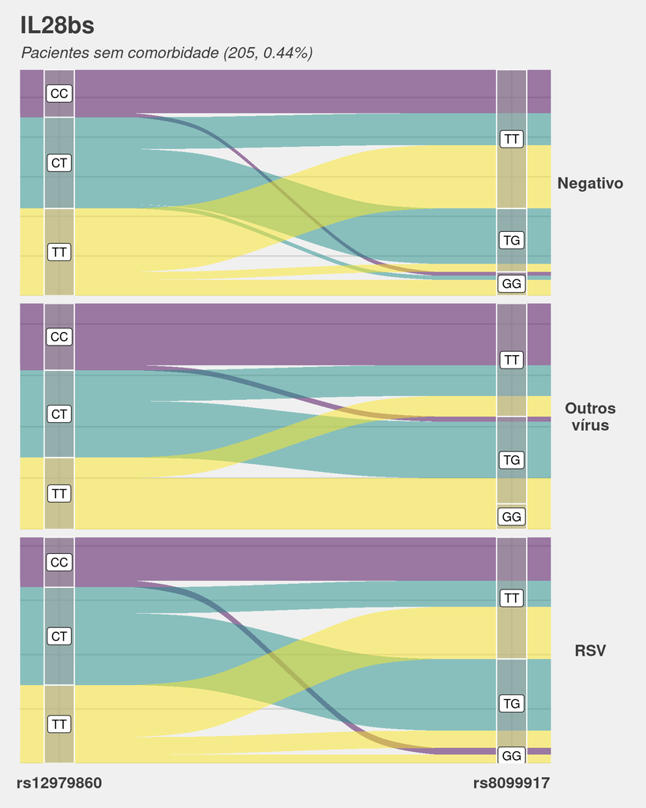

```
# A tibble: 10 x 5
   Par   Negativo `Outros\nvírus`   RSV Total
   <chr>    <dbl>           <dbl> <dbl> <dbl>
 1 CC/GG        2               0     3     5
 2 CC/TG        0               1     1     2
 3 CC/TT       16              20    33    69
 4 CT/GG        1               1     0     2
 5 CT/TG       32              13    58   103
 6 CT/TT       11              11    22    44
 7 TT/GG        7               6     5    18
 8 TT/TG        3               9    12    24
 9 TT/TT       22               8    38    68
10 Total       94              69   172   335
```

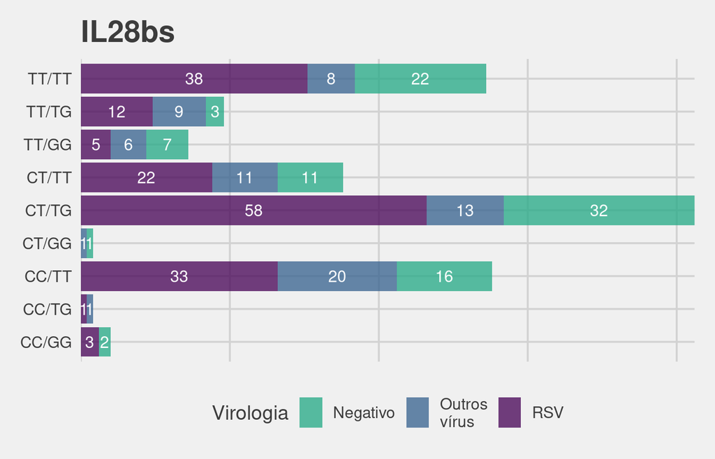

> Olhando apenas para os `sem comorbidade`

```
# A tibble: 10 x 5
   Par   Negativo `Outros\nvírus`   RSV Total
   <chr>    <dbl>           <dbl> <dbl> <dbl>
 1 CC/GG        1               0     3     4
 2 CC/TG        0               1     0     1
 3 CC/TT       11              12    20    43
 4 CT/GG        1               0     0     1
 5 CT/TG       14              11    33    58
 6 CT/TT        8               6    12    26
 7 TT/GG        4               5     4    13
 8 TT/TG        2               5     8    15
 9 TT/TT       16               4    24    44
10 Total       57              44   104   205
```

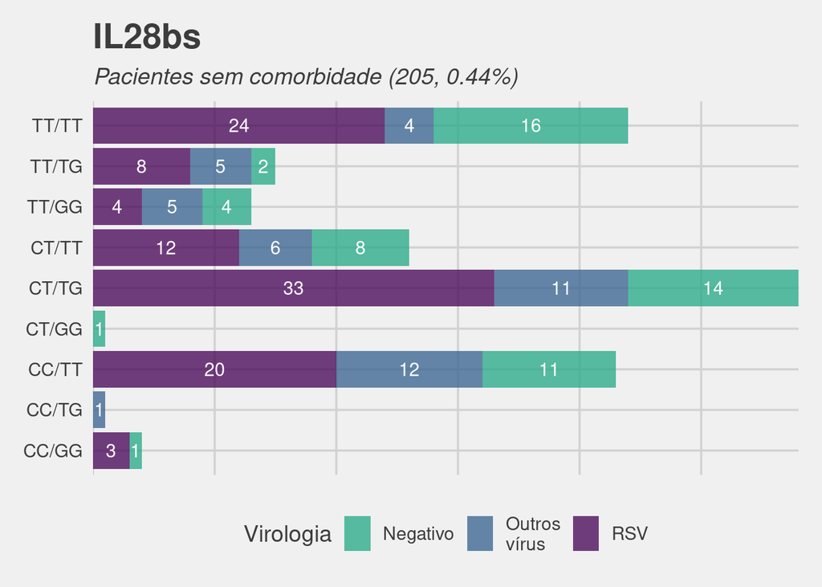

> Retirado os `negativos`

```
# A tibble: 2 x 10
  Tipo            `CC/GG` `CC/TG` `CC/TT` `CT/GG` `CT/TG` `CT/TT` `TT/GG` `TT/TG` `TT/TT`
  <chr>             <dbl>   <dbl>   <dbl>   <dbl>   <dbl>   <dbl>   <dbl>   <dbl>   <dbl>
1 "Outros\nvírus"       0       1      12       0      11       6       5       5       4
2 "RSV"                 3       0      20       0      33      12       4       8      24
```

```
# A tibble: 4 x 4
  SNPs  QuiQuadrado    df `p-valor`
  <chr>       <dbl> <dbl>     <dbl>
1 CC/TT         2       1  0.157
2 CT/TG        11       1  0.000911
3 CT/TT         2       1  0.157
4 TT/TT        14.3     1  0.000157
```

# PVZ

## a)

> **Analisar características clínicas e epidemiológicas dos lactentes elegíveis para uso do palivizumabe, adesão às doses e principais critérios de indicação**

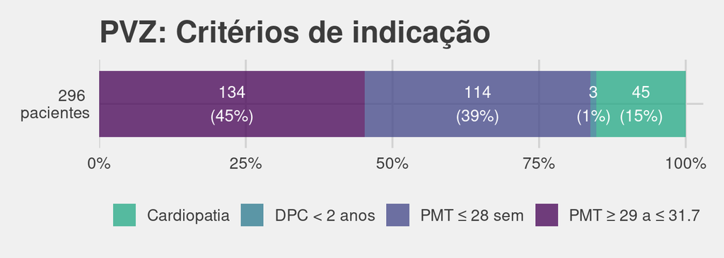

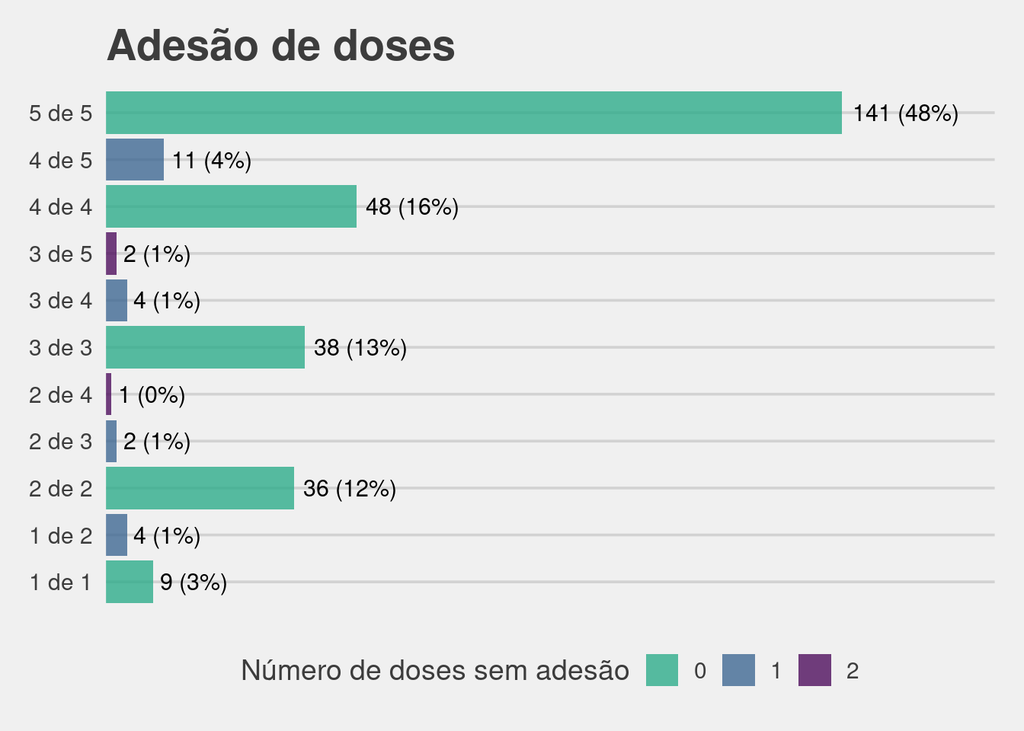

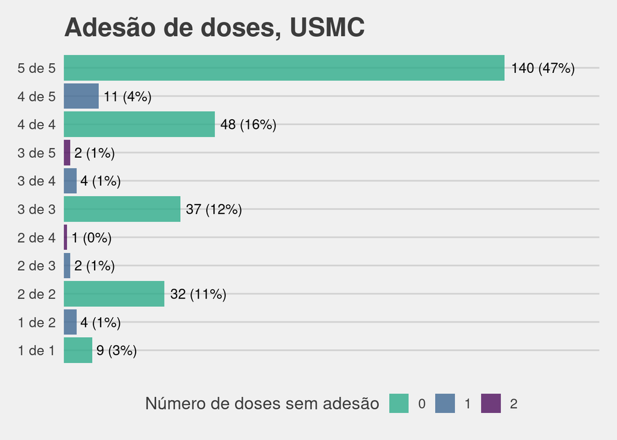

| Doses | Liberadas | Realizadas | AdesãoPerc |
| --- | --- | --- | --- |
| 1 | 290 | 290 | 100.000 |
| 2 | 281 | 277 | 98.577 |
| 3 | 245 | 242 | 98.776 |
| 4 | 206 | 199 | 96.602 |
| 5 | 153 | 140 | 91.503 |

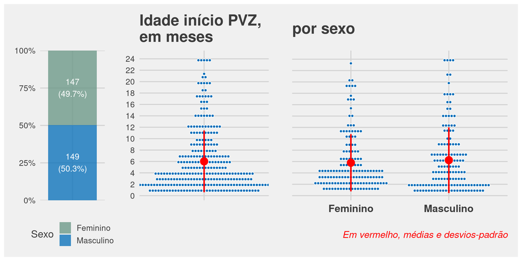

```
        Média StandardDeviation   n
[1,] 6.015203          5.420977 296
```

```
# A tibble: 2 x 4
  Sexo      `mean(IdadeIm)` `sd(IdadeIm)` `n()`
  <chr>               <dbl>         <dbl> <int>
1 Feminino             5.79          5.04   147
2 Masculino            6.24          5.78   149
```

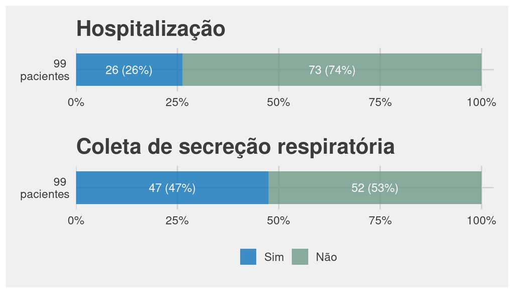

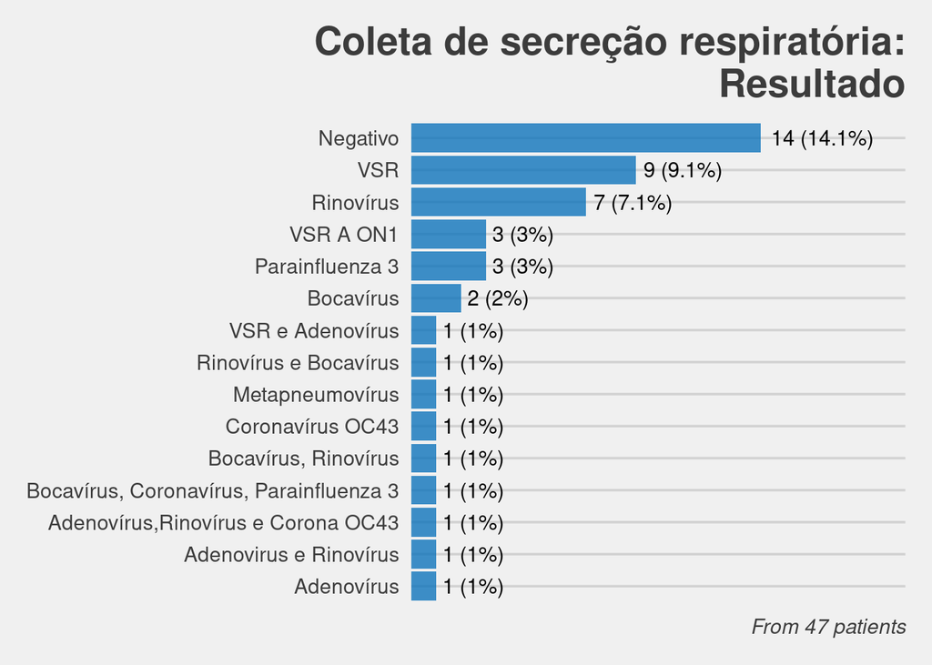

## b)

> **Avaliar dados clínicos e epidemiológicos dos lactantes que apresentaram falhas de prevenção pós-imunoprofilaxia e avaliar possíveis casos de resistência ao anticorpo monoclonal**

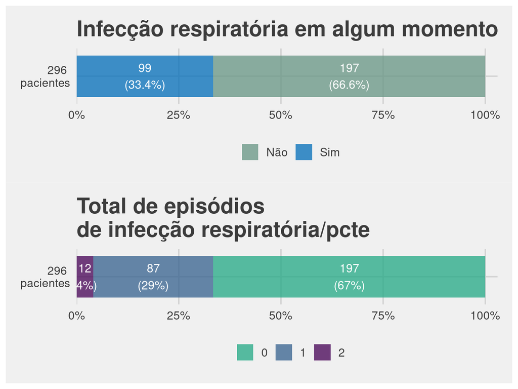

# Hipóteses a serem testadas

## a)

> **As infecções por VSR são mais graves em pacientes pediátricos < 2 anos, comparadas a infecções por outros vírus respiratórios.**

> Olhando para `internamento UTI`, existe diferença estatísticamente significativa entre `RSV` e `outros vírus`? **Sim, p-valor de 0.00158**

```
# A tibble: 2 x 3
  Virologia         Não   Sim
  <chr>           <int> <int>
1 "Outros\nvírus"    94    19
2 "RSV"             133    69
```

```
# A tibble: 1 x 4
  statistic p.value parameter method
      <dbl>   <dbl>     <int> <chr>
1      9.98 0.00158         1 Pearson's Chi-squared test with Yates' continuity correction
```

> Olhando para `tempo total de internamento`, existe diferença estatísticamente significativa em termos de tempo médio entre `RSV` (média de 9.97, 202 pacientes) e `outros vírus` (média de 9.38, 113 pacientes)? **Não, p-valor de 0.468**

```
# A tibble: 1 x 10
  estimate estimate1 estimate2 statistic p.value parameter conf.low conf.high method     alternative
     <dbl>     <dbl>     <dbl>     <dbl>   <dbl>     <dbl>    <dbl>     <dbl> <chr>      <chr>
1   -0.585      9.38      9.97    -0.727   0.468      266.    -2.17     0.999 Welch Two… two.sided
```

> Olhando para `desfecho`, existe diferença estatísticamente significativa entre `RSV` e `outros vírus`? **Sim, p-valor de 0.016**

```
# A tibble: 2 x 3
  Virologia        Alta Óbito
  <chr>           <int> <dbl>
1 "Outros\nvírus"   109     4
2 "RSV"             202     0
```

```
# A tibble: 1 x 6
  estimate p.value conf.low conf.high method                             alternative
     <dbl>   <dbl>    <dbl>     <dbl> <chr>                              <chr>
1        0  0.0160        0     0.835 Fisher's Exact Test for Count Data two.sided
```

> Olhando para `internação prévia`, existe diferença estatísticamente significativa entre `RSV` e `outros vírus`? **Sim, p-valor de 0.0000137**

```
# A tibble: 2 x 3
  Virologia         Não   Sim
  <chr>           <int> <int>
1 "Outros\nvírus"    72    41
2 "RSV"             173    29
```

```
# A tibble: 1 x 4
  statistic   p.value parameter method
      <dbl>     <dbl>     <int> <chr>
1      18.9 0.0000137         1 Pearson's Chi-squared test with Yates' continuity correction
```

> Olhando para `score gravidade`, existe diferença estatísticamente significativa entre `RSV` e `outros vírus`? **Sim, p-valor de 0.00123**

```
# A tibble: 2 x 4
  Virologia        Leve Médio Grave
  <chr>           <int> <int> <int>
1 "Outros\nvírus"    33    54    26
2 "RSV"              59    60    83
```

```
# A tibble: 1 x 4
  statistic p.value parameter method
      <dbl>   <dbl>     <int> <chr>
1      13.4 0.00123         2 Pearson's Chi-squared test
```

## b)

> **Fatores genéticos influenciam em maior suscetibilidade à infecção pelo VSR em crianças previamente saudáveis e sem comorbidades**

> IL28Bs? Se sim, já analizado.

## c)

> **A utilização de imunização passiva com PVZ diminui a frequência e gravidadade das infecções por RSV em pacientes pediátricos de alto risco**

> Olhando para `virologia RSV` e `score gravidade, grave`. Diferença estatísticamente significativa, p-valor de 0.0000000000000363 (3.63e-14)

```
# A tibble: 2 x 2
  PVZ       n
  <chr> <int>
1 Não      76
2 Sim       7
```

```
# A tibble: 1 x 4
  statistic  p.value parameter method
      <dbl>    <dbl>     <dbl> <chr>
1      57.4 3.63e-14         1 Chi-squared test for given probabilities
```